# Análisis Temporal y Demográfico de las Principales Causas de Muerte en Estados Unidos

**Autora:** Valerie M | **Fuente:** CDC – NCHS Leading Causes of Death, United States | **Período:** 1999‑2017

## 1. Introducción

### 1.1. Contexto del Problema

Las enfermedades crónicas no transmisibles constituyen la principal carga de mortalidad en Estados Unidos. Afecciones como las enfermedades cardíacas, el cáncer, las enfermedades cerebrovasculares, la diabetes, las enfermedades renales, la enfermedad de Alzheimer y las enfermedades respiratorias crónicas han figurado sistemáticamente entre las principales causas de defunción durante décadas. A este grupo se suman causas externas como los suicidios y las lesiones no intencionales (accidentes), que también representan una parte significativa de la mortalidad anual y responden a determinantes sociales y conductuales específicos.

Sin embargo, la mortalidad no se distribuye uniformemente en el territorio. Un estudio fundamental de James, Cossman y Wolf (2018) publicado en *Demographic Research* analizó 48 años de datos de mortalidad (1968-2015) y descubrió que las disparidades geográficas no son aleatorias, sino que persisten en el tiempo. Los condados con mortalidad persistentemente alta se concentran de manera desproporcionada en el Sur rural, particularmente en la división Este Sur Central (Kentucky, Tennessee, Mississippi y Alabama). La brecha entre esta región y el resto del país pasó de ~50 a 220 muertes por 100,000 habitantes, una diferencia que los autores denominan *"la diferencia entre el Corazón de América y Dixieland"*.

El presente estudio se centra en el periodo 1999-2017, prestando especial atención a las persistentes diferencias geográficas. Se analizarán las siguientes causas: enfermedades del corazón, cáncer, accidentes cerebrovasculares (stroke), enfermedades respiratorias crónicas (CLRD), accidentes no intencionales, Alzheimer, diabetes, enfermedades renales, influenza y neumonía, y suicidio.

### 1.2. Contexto del Dataset

El dataset utilizado es *"NCHS - Leading Causes of Death: United States"*, publicado por los **CDC** a través del **National Center for Health Statistics (NCHS)** y **National System of Vital Statistics (NVSS)**. Los datos provienen del registro universal de todos los fallecimientos emitidos en los 50 estados y el Distrito de Columbia.

### 1.3. Pregunta Central de Investigación

> **¿Cómo han cambiado las principales causas de muerte en Estados Unidos a lo largo del tiempo (1999‑2017) y qué diferencias persistentes se observan entre los distintos estados?**

Esta pregunta engloba tres dimensiones fundamentales:

1. **Temporal:** identificar tendencias, puntos de inflexión y cambios en la importancia relativa de las distintas causas de muerte.
2. **Geográfica:** analizar si la mortalidad afecta de manera diferente a los distintos estados y regiones.
3. **De ranking:** estudiar cómo varía la posición relativa de cada causa a lo largo del período.

### 1.4. Objetivos del Estudio

**General:** Realizar un análisis exploratorio de datos para caracterizar la evolución de la mortalidad en Estados Unidos entre 1999 y 2017, con énfasis en las principales causas de muerte y su distribución geográfica por estado.

**Específicos:**

1. Describir el panorama general de la mortalidad en EE.UU. (1999-2017).
2. Analizar la evolución temporal de las principales causas.
3. Evaluar las disparidades geográficas en mortalidad.
4. Visualizar la dinámica del ranking de causas de muerte.
5. Formular hipótesis e insights basados en los patrones encontrados.

## 2. Marco Teórico

> *Propósito: Sustentar el análisis con evidencia de la revisión de literatura especializada, estableciendo el estado del conocimiento sobre las tendencias y disparidades en mortalidad en Estados Unidos durante el periodo 1999-2017.*

### 2.1. El Predominio de las Enfermedades Crónicas en Estados Unidos

Estados Unidos completó hace décadas la transición epidemiológica que desplazó a las enfermedades infecciosas como principales causas de muerte, dando paso al predominio de las enfermedades crónicas y degenerativas. Desde mediados del siglo XX, afecciones como las enfermedades cardíacas, el cáncer y las enfermedades cerebrovasculares han ocupado consistentemente los primeros lugares en las estadísticas de mortalidad nacional (Shah et al., 2019).

Investigaciones recientes documentan que, tras décadas de reducción sostenida, la mortalidad por enfermedades cardiovasculares comenzó a estabilizarse alrededor de 2010. Paralelamente, otras causas como el Alzheimer, la diabetes y las enfermedades renales han incrementado su contribución relativa al total de defunciones, reflejando el envejecimiento poblacional y el aumento de condiciones metabólicas como la obesidad. Los accidentes, en particular, han mostrado un crecimiento en el siglo XXI, impulsados principalmente por intoxicaciones accidentales relacionadas con el consumo de drogas (Daugherty et al., 2019).

### 2.2. Las Disparidades Geográficas como Patrón Persistente

Uno de los hallazgos más sólidos en la literatura sobre mortalidad en Estados Unidos es la existencia de un "gradiente geográfico" que desfavorece sistemáticamente al Sureste del país. El estudio de James, Cossman y Wolf (2018) demostró que los condados con mortalidad persistentemente alta se concentran en la división Este Sur Central (Alabama, Kentucky, Mississippi y Tennessee). La brecha entre esta región y el resto del país pasó de 50 a 220 muertes por 100,000 habitantes en cinco décadas, un aumento que los autores atribuyen a factores estructurales como menor nivel socioeconómico, peor acceso a servicios de salud y mayor prevalencia de conductas de riesgo.

### 2.3. La Importancia del Análisis Temporal y por Ranking

Enfermedades como el Alzheimer han ascendido posiciones en el ranking nacional debido al envejecimiento poblacional, mientras que los accidentes han escalado posiciones impulsados por la crisis de opioides. Estos cambios en el ranking reflejan transformaciones en los perfiles de riesgo de la población y en la efectividad de las intervenciones de salud pública, por lo que su seguimiento resulta esencial.

## 3. Metodología

### 3.1. Herramientas y Librerías

El procesamiento y análisis se realiza en **Python** con las siguientes librerías equivalentes a las empleadas originalmente en R:

| Librería R | Equivalente Python | Función |
| --- | --- | --- |
| `tidyverse` / `dplyr` / `tidyr` | `pandas` | Manipulación y transformación de datos |
| `skimr` | `pandas-profiling` / `describe()` | Resúmenes descriptivos |
| `janitor` | `pandas` (str methods) | Limpieza de columnas |
| `ggplot2` / `RColorBrewer` | `matplotlib` / `seaborn` | Visualizaciones estáticas |
| `patchwork` | `matplotlib subplots` | Combinación de gráficos |
| `leaflet` / `tigris` / `sf` | `plotly` (choropleth + slider) | Mapas interactivos |
| `kableExtra` | `pandas` + `IPython.display` | Tablas formateadas |

### 3.2. Variables del Dataset

| Columna original | Descripción | Nombre en el análisis | Tipo |
| --- | --- | --- | --- |
| Year | Año de registro | `anio` | Numérico (entero) |
| 113 Cause Name | Código ICD-10 | `causa_codigo` | Texto |
| Cause Name | Nombre de la causa | `causa` | Texto |
| State | Estado de residencia | `estado` | Texto |
| Deaths | Número de muertes | `muertes` | Numérico (entero) |
| Age-adjusted Death Rate | Tasa ajustada por edad (por 100,000 hab.) | `tasa_ajustada` | Numérico (double) |

Para facilitar el análisis, las variables fueron renombradas como: `anio`, `causa_codigo`, `causa`, `estado`, `muertes` y `tasa_ajustada`. No se incluyen variables demográficas como sexo o grupo etario, por lo que el análisis se centra en las dimensiones temporal, geográfica y de ranking.

```python
import pandas as pd
import numpy as np
import matplotlib.pyplot as plt
import matplotlib.ticker as mticker
import matplotlib.patches as mpatches
import seaborn as sns
import warnings
warnings.filterwarnings('ignore')

# Configuración global de estilo
plt.rcParams.update({
    'figure.dpi': 120,
    'figure.facecolor': 'white',
    'axes.facecolor': 'white',
    'axes.spines.top': False,
    'axes.spines.right': False,
})

print("✓ Librerías cargadas correctamente.")
```

```
✓ Librerías cargadas correctamente.
```

```python
# ── Carga del dataset ──────────────────────────────────────────────────────
# Se coloca el CSV
FILE = r"C:\Users\luisc\Datos\NCHS_-_Leading_Causes_of_Death__United_States_20260227.csv"

df_raw = pd.read_csv(FILE)
print(f"Shape original: {df_raw.shape}")
print(df_raw.head(3))
```

[output not shown]

```python
#Se coloca el CSV en la misma carpeta que este notebook
FILE = r"C:\Users\luisc\Datos\NCHS_-_Leading_Causes_of_Death__United_States_20260227.csv"

df_raw = pd.read_csv(FILE)
print(f"Shape original: {df_raw.shape}")
print(df_raw.head(3))
```

```
Shape original: (10868, 6)
   Year                                     113 Cause Name      Cause Name  \
0  2012  Nephritis, nephrotic syndrome and nephrosis (N...  Kidney disease
1  2017  Nephritis, nephrotic syndrome and nephrosis (N...  Kidney disease
2  2016  Nephritis, nephrotic syndrome and nephrosis (N...  Kidney disease

     State Deaths Age-adjusted Death Rate
0  Vermont     21                     2,6
1  Vermont     29                     3,3
2  Vermont     30                     3,7
```

```python
# ── Limpieza y transformación ────────────────────────────────────────────────

# Limpiar nombres de columnas
df_raw.columns = (
    df_raw.columns.str.strip().str.lower()
    .str.replace(' ', '_').str.replace('-', '_')
)

# Renombrar columnas clave
rename_map = {
    'year': 'anio',
    '113_cause_name': 'causa_codigo',
    'cause_name': 'causa',
    'state': 'estado',
    'deaths': 'muertes',
    'age_adjusted_death_rate': 'tasa_ajustada'
}
rename_map = {k: v for k, v in rename_map.items() if k in df_raw.columns}
df = df_raw.rename(columns=rename_map).copy()

# Convertir tipos
df['muertes'] = pd.to_numeric(
    df['muertes'].astype(str).str.replace(',', '', regex=False),
    errors='coerce'
)
df['tasa_ajustada'] = pd.to_numeric(
    df['tasa_ajustada'].astype(str).str.replace(',', '.', regex=False),
    errors='coerce'
)
df['anio'] = pd.to_numeric(df['anio'], errors='coerce')

# ── Dataset nacional: solo filas de "United States", período 1999-2017
datos = df[
    (df['estado'] == 'United States') &
    (df['anio'] >= 1999) &
    (df['anio'] <= 2017)
][['anio', 'causa', 'muertes', 'tasa_ajustada']].copy()

# ── Dataset por estados: excluir "United States", período 1999-2017
datos_estados = df[
    (df['estado'] != 'United States') &
    (df['anio'] >= 1999) &
    (df['anio'] <= 2017)
].copy()

# Totales nacionales por año
totales_anuales = datos[datos['causa'] == 'All causes'][['anio', 'muertes']].copy()
print("\nTotales nacionales por año:")
print(totales_anuales.to_string(index=False))

# Total acumulado por causa
totales_causa = (
    datos[datos['causa'] != 'All causes']
    .groupby('causa')['muertes'].sum()
    .sort_values(ascending=False)
    .reset_index(name='total_1999_2017')
)
print("\nTotal acumulado por causa (1999-2017):")
print(totales_causa.to_string(index=False))
```

```
Totales nacionales por año:
 anio  muertes
 2014      NaN
 2016      NaN
 2017      NaN
 2013      NaN
 2012      NaN
 2015      NaN
 2011      NaN
 2010      NaN
 2009      NaN
 2008      NaN
 2007      NaN
 2006      NaN
 2004      NaN
 2005      NaN
 2003      NaN
 2002      NaN
 2001      NaN
 2000      NaN
 1999      NaN

Total acumulado por causa (1999-2017):
                  causa  total_1999_2017
          Heart disease        12222.640
                 Cancer        10843.644
                 Stroke         2726.523
                   CLRD         2594.927
 Unintentional injuries         2347.820
    Alzheimer's disease         1494.816
               Diabetes         1399.943
Influenza and pneumonia         1094.641
         Kidney disease          858.613
                Suicide          697.016
```

## 3.3. Comparación porcentual de muertes por causa: 1999 vs 2017

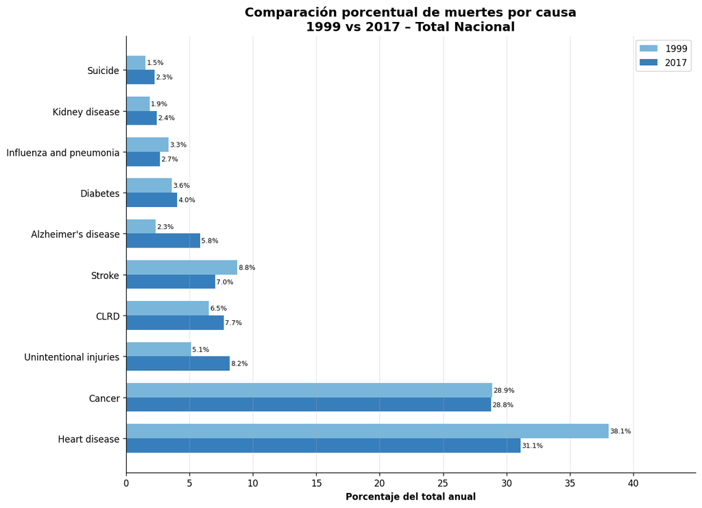

```python
datos_comp = datos[
    (datos['anio'].isin([1999, 2017])) &
    (datos['causa'] != 'All causes')
].copy()

datos_comp['total_anual'] = datos_comp.groupby('anio')['muertes'].transform('sum')
datos_comp['porcentaje'] = datos_comp['muertes'] / datos_comp['total_anual'] * 100

# Ordenar por porcentaje 2017
orden_causas = (
    datos_comp[datos_comp['anio'] == 2017]
    .sort_values('porcentaje', ascending=False)['causa'].tolist()
)

pivot = datos_comp.pivot(index='causa', columns='anio', values='porcentaje').loc[orden_causas]

fig, ax = plt.subplots(figsize=(11, 8))
y = np.arange(len(pivot))
h = 0.35

bars1 = ax.barh(y + h/2, pivot[1999], h, label='1999', color='#6baed6', alpha=0.9)
bars2 = ax.barh(y - h/2, pivot[2017], h, label='2017', color='#2171b5', alpha=0.9)

for bar in list(bars1) + list(bars2):
    w = bar.get_width()
    ax.text(w + 0.1, bar.get_y() + bar.get_height()/2,
            f'{w:.1f}%', va='center', fontsize=7.5)

ax.set_yticks(y)
ax.set_yticklabels(pivot.index, fontsize=10)
ax.set_xlabel('Porcentaje del total anual', fontweight='bold')
ax.set_title('Comparación porcentual de muertes por causa\n1999 vs 2017 – Total Nacional',
             fontsize=14, fontweight='bold')
ax.legend()
ax.grid(axis='x', alpha=0.3)
ax.set_xlim(0, pivot.max().max() * 1.18)
plt.tight_layout()
plt.show()
```

## 4. Evolución de la Tasa Ajustada de Mortalidad Anual

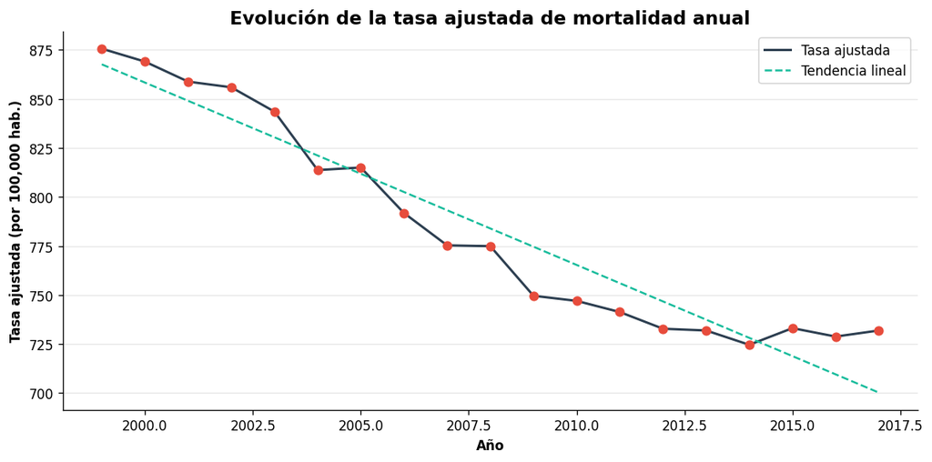

```python
from scipy import stats

total_anual = datos[datos['causa'] == 'All causes'].sort_values('anio')

fig, ax = plt.subplots(figsize=(10, 5))
ax.plot(total_anual['anio'], total_anual['tasa_ajustada'],
        color='#2C3E50', linewidth=1.8, label='Tasa ajustada')
ax.scatter(total_anual['anio'], total_anual['tasa_ajustada'],
           color='#E74C3C', s=40, zorder=5)

# Tendencia lineal (equivalente a geom_smooth lm)
slope, intercept, *_ = stats.linregress(total_anual['anio'], total_anual['tasa_ajustada'])
x_fit = np.array([1999, 2017])
ax.plot(x_fit, slope * x_fit + intercept,
        color='#18BC9C', linestyle='--', linewidth=1.5, label='Tendencia lineal')

ax.yaxis.set_major_formatter(mticker.FuncFormatter(lambda x, _: f'{x:,.0f}'))
ax.set_xlabel('Año', fontweight='bold')
ax.set_ylabel('Tasa ajustada (por 100,000 hab.)', fontweight='bold')
ax.set_title('Evolución de la tasa ajustada de mortalidad anual', fontsize=14, fontweight='bold')
ax.legend()
ax.grid(axis='y', alpha=0.3)
plt.tight_layout()
plt.show()
```

## 5. Análisis de Ranking: Cambios en la Posición de las Causas de Muerte

El ranking de causas de muerte no es estático. Analizar cómo cambia la posición relativa de cada causa a lo largo del tiempo permite identificar qué enfermedades ganan o pierden importancia en la carga de mortalidad.

### 5.1. Ranking de causas por año

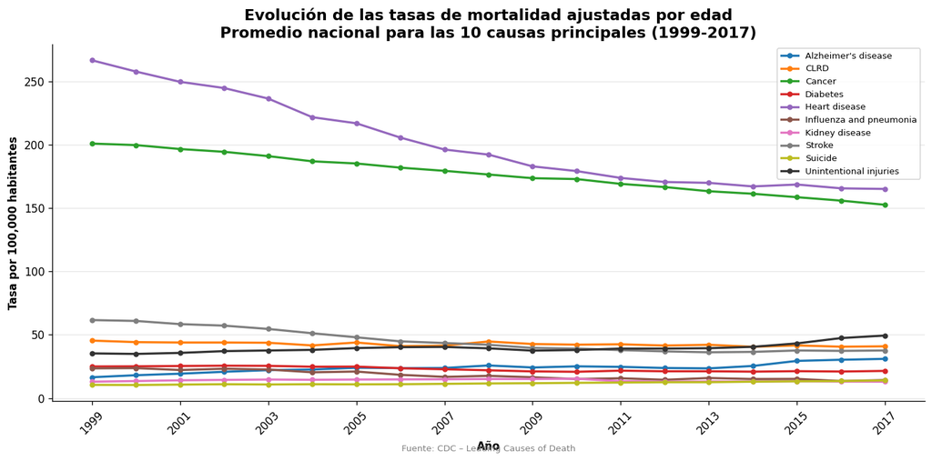

```python
# Top 10 causas por tasa promedio
top10_tasas = (
    datos[datos['causa'] != 'All causes']
    .groupby('causa')['tasa_ajustada']
    .mean()
    .nlargest(10)
    .index.tolist()
)

datos_tasas_nac = (
    datos[datos['causa'].isin(top10_tasas)]
    .groupby(['anio', 'causa'], as_index=False)['tasa_ajustada']
    .mean()
    .rename(columns={'tasa_ajustada': 'tasa_nac'})
)

# Paleta tipo Set1 + gris oscuro
from matplotlib.cm import get_cmap
base_colors = [plt.cm.tab10(i) for i in range(9)] + [(0.2, 0.2, 0.2, 1)]
causas_ord = sorted(datos_tasas_nac['causa'].unique())
color_map = dict(zip(causas_ord, base_colors[:len(causas_ord)]))

fig, ax = plt.subplots(figsize=(12, 6))
for causa, grp in datos_tasas_nac.groupby('causa'):
    ax.plot(grp['anio'], grp['tasa_nac'], label=causa,
            color=color_map[causa], linewidth=2, marker='o', markersize=4)

ax.set_xticks(range(1999, 2018, 2))
ax.tick_params(axis='x', rotation=45)
ax.set_xlabel('Año', fontweight='bold')
ax.set_ylabel('Tasa por 100,000 habitantes', fontweight='bold')
ax.set_title('Evolución de las tasas de mortalidad ajustadas por edad\nPromedio nacional para las 10 causas principales (1999-2017)',
             fontsize=14, fontweight='bold')
ax.legend(fontsize=8, loc='upper right', framealpha=0.8)
ax.grid(axis='y', alpha=0.3)
ax.text(0.5, -0.14, 'Fuente: CDC – Leading Causes of Death',
        transform=ax.transAxes, ha='center', fontsize=8, color='gray')
plt.tight_layout()
plt.show()
```

**Interpretación:** La gráfica evidencia que las **enfermedades cardíacas** y el **cáncer** presentan las tasas más altas, aunque ambas muestran una tendencia descendente sostenida, lo que sugiere avances en prevención y tratamiento. En contraste, las **lesiones no intencionales** exhiben un incremento progresivo, reflejando un cambio en factores sociales y ambientales. El **Alzheimer** destaca por un aumento gradual, vinculado al envejecimiento poblacional. En conjunto, el análisis confirma una transición epidemiológica: reducción en enfermedades crónicas tradicionales, pero crecimiento en causas relacionadas con la longevidad y accidentes.

### 5.2. Cambios en el ranking: 1999 vs 2017

```python
# Agregar ranking por año
datos_nacional = (
    datos[datos['causa'] != 'All causes']
    .copy()
)
datos_nacional['rank'] = datos_nacional.groupby('anio')['muertes'].rank(
    ascending=False, method='min').astype(int)

def get_rank(year):
    return (
        datos_nacional[datos_nacional['anio'] == year]
        [['causa', 'rank', 'muertes']]
        .rename(columns={'rank': f'rank_{year}', 'muertes': f'muertes_{year}'})
    )

cambios = get_rank(1999).merge(get_rank(2017), on='causa')
cambios['cambio_rank'] = cambios['rank_2017'] - cambios['rank_1999']
cambios['pct_cambio'] = (
    (cambios['muertes_2017'] - cambios['muertes_1999']) / cambios['muertes_1999'] * 100
).round(1)
cambios['cambio_fmt'] = cambios['cambio_rank'].apply(
    lambda x: f'▲ {abs(int(x))}' if x < 0 else (f'▼ {int(x)}' if x > 0 else '=')
)

tabla_cambios = (
    cambios[['causa', 'rank_1999', 'rank_2017', 'cambio_fmt', 'pct_cambio']]
    .sort_values('rank_1999')
    .rename(columns={'causa': 'Causa', 'rank_1999': 'Rank 1999',
                     'rank_2017': 'Rank 2017', 'cambio_fmt': 'Cambio', 'pct_cambio': 'Variación %'})
)

from IPython.display import display, HTML

def colorear_tabla(df):
    def color_cambio(val):
        if '▲' in str(val): return 'color: green; font-weight: bold'
        if '▼' in str(val): return 'color: red; font-weight: bold'
        return ''
    def color_pct(val):
        try:
            v = float(val)
            return f'color: {"red" if v > 0 else "green"}; {"font-weight:bold" if abs(v) > 10 else ""}'
        except: return ''
    styled = (
        df.style
        .map(color_cambio, subset=['Cambio'])
        .map(color_pct, subset=['Variación %'])
        .set_table_styles([
            {'selector': 'thead th', 'props': [('background-color','#04376B'),
                                                ('color','white'),('font-weight','bold')]}
        ])
        .set_caption('Cambios en el ranking de causas de muerte (1999‑2017)')
        .hide(axis='index')
    )
    return styled

display(colorear_tabla(tabla_cambios))
```

Cambios en el ranking de causas de muerte (1999‑2017)

| Causa | Rank 1999 | Rank 2017 | Cambio | Variación % |
| --- | --- | --- | --- | --- |
| Heart disease | 1 | 1 | = | -10.700000 |
| Cancer | 2 | 2 | = | 9.000000 |
| Stroke | 3 | 5 | ▼ 2 | -12.500000 |
| CLRD | 4 | 4 | = | 29.000000 |
| Unintentional injuries | 5 | 3 | ▲ 2 | 73.700000 |
| Diabetes | 6 | 7 | ▼ 1 | 22.200000 |
| Influenza and pneumonia | 7 | 8 | ▼ 1 | -12.600000 |
| Alzheimer's disease | 8 | 6 | ▲ 2 | 172.600000 |
| Kidney disease | 9 | 9 | = | 42.500000 |
| Suicide | 10 | 10 | = | 61.600000 |

**Interpretación:** La tabla de **cambios en el ranking de causas de muerte (1999-2017)** evidencia transformaciones importantes en el perfil epidemiológico: las **enfermedades cardíacas** y el **cáncer** se mantienen como las dos principales causas, aunque con variaciones porcentuales moderadas (-10.7% y +9.0% respectivamente). En contraste, las **lesiones no intencionales** suben del puesto **5** al **3** con un incremento del **73.7%**, y el **Alzheimer** asciende del **8** al **6** con un aumento notable del **172.6%**, reflejando el impacto del envejecimiento poblacional. Por otro lado, causas como el **stroke** bajan del **3** al **5** (-12.5%) y la **influenza/neumonía** del **7** al **8** (-12.6%), mostrando menor peso relativo.

## 6. Análisis Específico: La Crisis de las "Muertes por Desesperación"

Como se discutió en el marco teórico (sección 2.1), el aumento de suicidios y accidentes (especialmente sobredosis) ha sido uno de los fenómenos más preocupantes en la mortalidad de EE.UU. durante el periodo de estudio.

### 6.1. Evolución conjunta de suicidio y accidentes

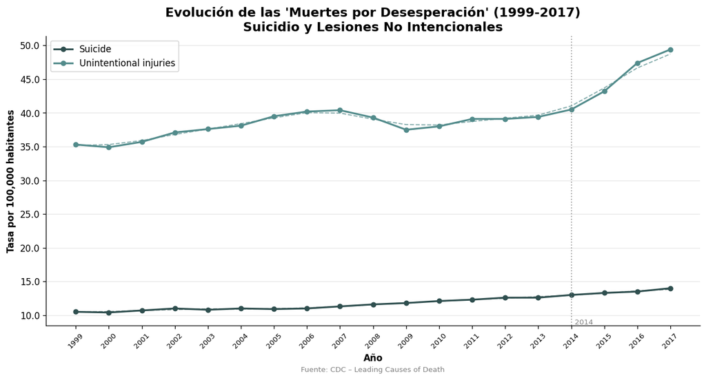

```python
from scipy.ndimage import uniform_filter1d

causas_d = ['Suicide', 'Unintentional injuries']
datos_d = datos_nacional[datos_nacional['causa'].isin(causas_d)].copy()
datos_d['anio'] = datos_d['anio'].astype(int)

colors_d = {'Suicide': '#2F4F4F', 'Unintentional injuries': '#528B8B'}

fig, ax = plt.subplots(figsize=(11, 6))

for causa, grp in datos_d.groupby('causa'):
    grp = grp.sort_values('anio')
    ax.plot(grp['anio'], grp['tasa_ajustada'],
            color=colors_d[causa], linewidth=2, marker='o', markersize=5, label=causa)
    # Tendencia suavizada (equivalente a geom_smooth)
    suave = uniform_filter1d(grp['tasa_ajustada'].values, size=3)
    ax.plot(grp['anio'], suave, color=colors_d[causa],
            linestyle='--', linewidth=1.2, alpha=0.7)

# Línea vertical: aceleración desde 2014
ax.axvline(2014, color='gray', linestyle=':', linewidth=1.2, alpha=0.7)
ax.text(2014.1, ax.get_ylim()[0] * 1.02, '2014', color='gray', fontsize=8)

ax.set_xticks(range(1999, 2018))
ax.tick_params(axis='x', rotation=45, labelsize=8)
ax.set_xlabel('Año', fontweight='bold')
ax.set_ylabel('Tasa por 100,000 habitantes', fontweight='bold')
ax.set_title("Evolución de las 'Muertes por Desesperación' (1999-2017)\nSuicidio y Lesiones No Intencionales",
             fontsize=14, fontweight='bold')
ax.legend(loc='upper left')
ax.yaxis.set_major_formatter(mticker.FuncFormatter(lambda x, _: f'{x:.1f}'))
ax.grid(axis='y', alpha=0.3)
ax.text(0.5, -0.16, 'Fuente: CDC – Leading Causes of Death',
        transform=ax.transAxes, ha='center', fontsize=8, color='gray')
plt.tight_layout()
plt.show()
```

## 7. Distribución por Causas Principales (Top 10)

```python
top10 = pd.DataFrame({
    'causa': ['Heart disease', 'Cancer', 'Unintentional injuries',
              'CLRD', 'Stroke', 'Diabetes',
              "Alzheimer's disease", 'Kidney disease',
              'Influenza and pneumonia', 'Suicide'],
    'total_muertes': [326637, 281998, 247735, 207523, 192144,
                      170364, 144783, 143719, 53128, 48875]
})

# Tabla
print("Top 10 causas de muerte en EE.UU. (1999-2017)\n")
print(f"{'Causa':<30} {'Total de muertes':>20}")
print("-" * 52)
for _, row in top10.iterrows():
    print(f"{row['causa']:<30} {row['total_muertes']:>20,}")
print("\nFuente: CDC - Leading Causes of Death")
```

[output not shown]

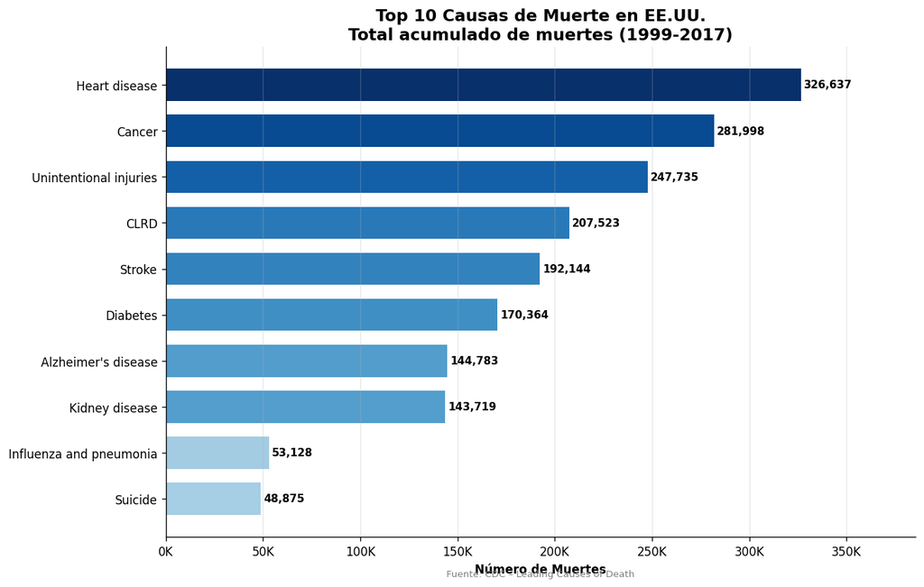

```python
# Gráfico de barras horizontales con degradado
top10_ord = top10.sort_values('total_muertes').copy()

norm = plt.Normalize(top10_ord['total_muertes'].min(), top10_ord['total_muertes'].max())
cmap = plt.cm.Blues
colors_bar = [cmap(0.35 + 0.65 * norm(v)) for v in top10_ord['total_muertes']]

fig, ax = plt.subplots(figsize=(11, 7))
bars = ax.barh(top10_ord['causa'], top10_ord['total_muertes'],
               color=colors_bar, height=0.7)

for bar, val in zip(bars, top10_ord['total_muertes']):
    ax.text(val + 1500, bar.get_y() + bar.get_height()/2,
            f'{val:,}', va='center', fontweight='bold', fontsize=9)

ax.set_xlabel('Número de Muertes', fontweight='bold')
ax.set_title('Top 10 Causas de Muerte en EE.UU.\nTotal acumulado de muertes (1999-2017)',
             fontsize=14, fontweight='bold')
ax.xaxis.set_major_formatter(mticker.FuncFormatter(lambda x, _: f'{x/1e3:.0f}K'))
ax.set_xlim(0, top10_ord['total_muertes'].max() * 1.18)
ax.grid(axis='x', alpha=0.3)
ax.text(0.5, -0.08, 'Fuente: CDC – Leading Causes of Death',
        transform=ax.transAxes, ha='center', fontsize=8, color='gray')
plt.tight_layout()
plt.show()
```

## 8. Series de Tiempo por Causa

### 8.1. Paneles de tasa ajustada por causa

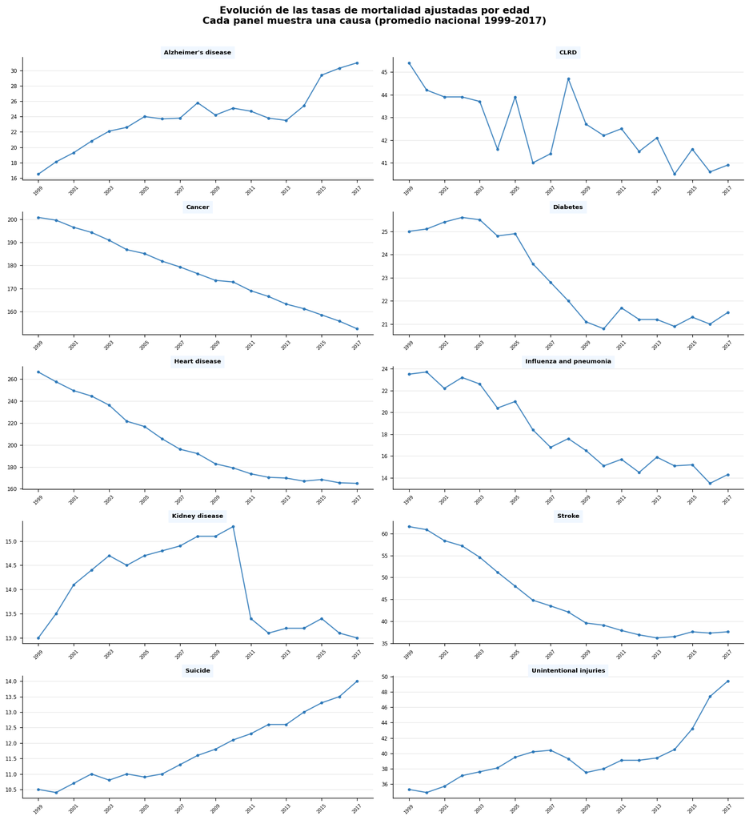

```python
tasas_nac = (
    datos[datos['causa'] != 'All causes']
    .groupby(['anio', 'causa'], as_index=False)['tasa_ajustada']
    .mean()
)

causas_u = sorted(tasas_nac['causa'].unique())
n = len(causas_u)
ncols = 2
nrows = (n + 1) // ncols

fig, axes = plt.subplots(nrows, ncols, figsize=(14, nrows * 3))
axes = axes.flatten()

for i, causa in enumerate(causas_u):
    ax = axes[i]
    sub = tasas_nac[tasas_nac['causa'] == causa].sort_values('anio')
    ax.plot(sub['anio'], sub['tasa_ajustada'],
            color='#2171B5', linewidth=1.5, marker='o', markersize=3, alpha=0.8)
    ax.set_title(causa, fontweight='bold', fontsize=8,
                 backgroundcolor='#F0F7FF', pad=4)
    ax.set_xticks(range(1999, 2018, 2))
    ax.tick_params(axis='x', rotation=45, labelsize=6)
    ax.tick_params(axis='y', labelsize=7)
    ax.grid(axis='y', alpha=0.3)
    ax.spines['top'].set_visible(False)
    ax.spines['right'].set_visible(False)

for j in range(i + 1, len(axes)):
    axes[j].set_visible(False)

fig.suptitle('Evolución de las tasas de mortalidad ajustadas por edad\nCada panel muestra una causa (promedio nacional 1999-2017)',
             fontsize=13, fontweight='bold', y=1.01)
plt.tight_layout()
plt.show()
```

**Interpretación:** La gráfica muestra cómo han cambiado las principales causas de muerte entre 1999 y 2017. Se observa un patrón claro: las **enfermedades cardíacas** y el **cáncer** presentan las tasas más altas pero con una tendencia descendente, lo que refleja avances en prevención y tratamiento; en contraste, el **Alzheimer** y las **lesiones no intencionales** muestran un aumento sostenido, vinculado al envejecimiento poblacional y a factores sociales. Es relevante porque evidencia una **transición epidemiológica**: mientras algunas enfermedades crónicas tradicionales disminuyen, emergen con fuerza nuevas amenazas asociadas a la longevidad y a riesgos externos.

### 8.2. Heatmap de muertes absolutas por causa y año

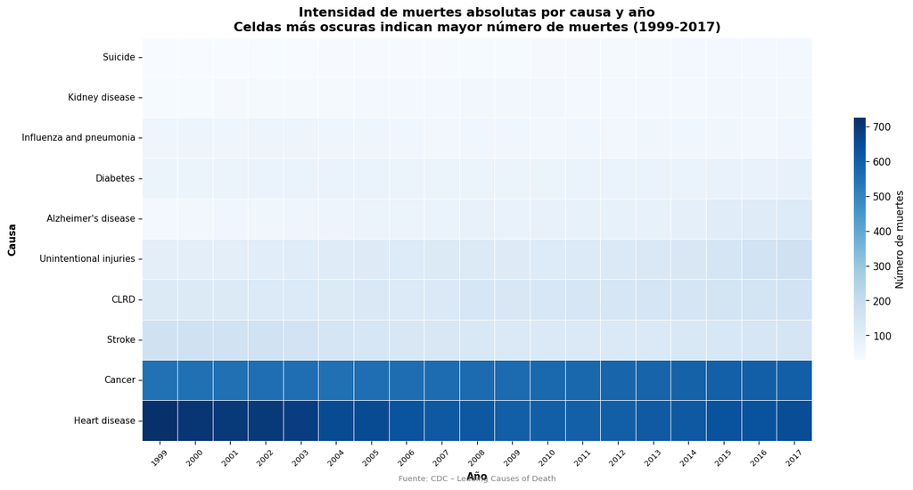

```python
pivot_heat = (
    datos[datos['causa'] != 'All causes']
    .pivot(index='causa', columns='anio', values='muertes')
)
pivot_heat = pivot_heat.loc[pivot_heat.sum(axis=1).sort_values().index]

fig, ax = plt.subplots(figsize=(14, 7))
sns.heatmap(pivot_heat, cmap='Blues', ax=ax,
            linewidths=0.3, linecolor='white',
            cbar_kws={'label': 'Número de muertes', 'shrink': 0.6})
ax.set_title('Intensidad de muertes absolutas por causa y año\nCeldas más oscuras indican mayor número de muertes (1999-2017)',
             fontsize=13, fontweight='bold')
ax.set_xlabel('Año', fontweight='bold')
ax.set_ylabel('Causa', fontweight='bold')
ax.tick_params(axis='x', rotation=45, labelsize=8)
ax.tick_params(axis='y', labelsize=9)
ax.text(0.5, -0.10, 'Fuente: CDC – Leading Causes of Death',
        transform=ax.transAxes, ha='center', fontsize=8, color='gray')
plt.tight_layout()
plt.show()
```

### 8.3. Análisis Geográfico: Disparidades por Estado

Las tasas de mortalidad no se distribuyen de manera homogénea en el territorio estadounidense. En esta sección se exploran dichas disparidades utilizando las **tasas ajustadas por edad**, que eliminan el efecto de las diferentes estructuras poblacionales y permiten comparaciones justas entre regiones.

#### 8.3.1. Mapa interactivo con slider – Número de muertes por estado (1999-2017)

> **Requiere:** `pip install plotly` — Equivalente Python del mapa leaflet interactivo con slider de año en R.

```python
try:
    import plotly.express as px
    import plotly.graph_objects as go

    # Dataset: todas causas, por estado, excluyendo US total
    mapa_muertes = datos_estados[
        (datos_estados['causa'] == 'All causes') &
        (datos_estados['estado'].notna())
    ][['anio', 'estado', 'muertes']].dropna().copy()
    mapa_muertes['anio'] = mapa_muertes['anio'].astype(int)

    # Abreviaturas de estados (necesarias para plotly choropleth)
    abbrev = {
        'Alabama':'AL','Alaska':'AK','Arizona':'AZ','Arkansas':'AR','California':'CA',
        'Colorado':'CO','Connecticut':'CT','Delaware':'DE','Florida':'FL','Georgia':'GA',
        'Hawaii':'HI','Idaho':'ID','Illinois':'IL','Indiana':'IN','Iowa':'IA',
        'Kansas':'KS','Kentucky':'KY','Louisiana':'LA','Maine':'ME','Maryland':'MD',
        'Massachusetts':'MA','Michigan':'MI','Minnesota':'MN','Mississippi':'MS',
        'Missouri':'MO','Montana':'MT','Nebraska':'NE','Nevada':'NV','New Hampshire':'NH',
        'New Jersey':'NJ','New Mexico':'NM','New York':'NY','North Carolina':'NC',
        'North Dakota':'ND','Ohio':'OH','Oklahoma':'OK','Oregon':'OR','Pennsylvania':'PA',
        'Rhode Island':'RI','South Carolina':'SC','South Dakota':'SD','Tennessee':'TN',
        'Texas':'TX','Utah':'UT','Vermont':'VT','Virginia':'VA','Washington':'WA',
        'West Virginia':'WV','Wisconsin':'WI','Wyoming':'WY',
        'District of Columbia':'DC'
    }
    mapa_muertes['codigo'] = mapa_muertes['estado'].map(abbrev)
    mapa_muertes = mapa_muertes.dropna(subset=['codigo'])

    fig_map = px.choropleth(
        mapa_muertes,
        locations='codigo',
        locationmode='USA-states',
        color='muertes',
        animation_frame='anio',
        color_continuous_scale='Blues',
        scope='usa',
        hover_name='estado',
        hover_data={'muertes': ':,', 'codigo': False},
        labels={'muertes': 'Número de muertes', 'anio': 'Año'},
        title='Número de muertes por estado (1999-2017) – desliza el slider para cambiar el año',
        range_color=[mapa_muertes['muertes'].quantile(0.02),
                     mapa_muertes['muertes'].quantile(0.98)]
    )
    fig_map.update_layout(
        title_font_size=13,
        coloraxis_colorbar_title='Muertes',
        geo=dict(showlakes=True, lakecolor='rgb(255,255,255)'),
        height=500
    )
    fig_map.show()

except Exception as e:
    print(f"Error: {e}")
```

[output not shown]

#### 8.3.2. Mapa interactivo con slider – Tasa de mortalidad ajustada por edad (1999-2017)

```python
try:
    import plotly.express as px

    mapa_tasas = datos_estados[
        (datos_estados['causa'] == 'All causes') &
        (datos_estados['estado'].notna())
    ][['anio', 'estado', 'tasa_ajustada']].dropna().copy()
    mapa_tasas['anio'] = mapa_tasas['anio'].astype(int)
    mapa_tasas['codigo'] = mapa_tasas['estado'].map(abbrev)
    mapa_tasas = mapa_tasas.dropna(subset=['codigo'])

    fig_tasas = px.choropleth(
        mapa_tasas,
        locations='codigo',
        locationmode='USA-states',
        color='tasa_ajustada',
        animation_frame='anio',
        color_continuous_scale='Blues',
        scope='usa',
        hover_name='estado',
        hover_data={'tasa_ajustada': ':.1f', 'codigo': False},
        labels={'tasa_ajustada': 'Tasa ajustada (por 100,000)', 'anio': 'Año'},
        title='Tasa de mortalidad ajustada por estado (1999-2017) – desliza el slider',
        range_color=[mapa_tasas['tasa_ajustada'].quantile(0.05),
                     mapa_tasas['tasa_ajustada'].quantile(0.95)]
    )
    fig_tasas.update_layout(
        title_font_size=13,
        coloraxis_colorbar_title='Tasa<br>por 100,000',
        geo=dict(showlakes=True, lakecolor='rgb(255,255,255)'),
        height=500
    )
    fig_tasas.show()

except ImportError:
    print("Plotly no está instalado. Ejecuta: pip install plotly")
```

[output not shown]

#### 8.3.3. Estados con mayor y menor mortalidad

```
Estados con MAYOR tasa de mortalidad – 2017:
       estado  tasa
West Virginia 957.1
  Mississippi 951.3
     Kentucky 929.9
      Alabama 917.7
     Oklahoma 902.4

Estados con MENOR tasa de mortalidad – 2017:
     estado  tasa
  Minnesota 656.4
Connecticut 651.2
   New York 623.6
 California 618.7
     Hawaii 584.9
```

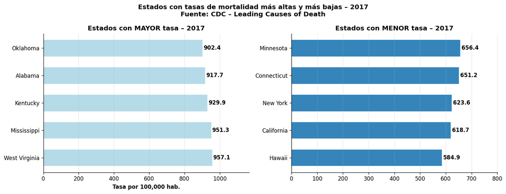

```python
anio_sel = 2017

tasas_estado = (
    datos_estados[
        (datos_estados['causa'] == 'All causes') &
        (datos_estados['anio'] == anio_sel)
    ]
    .groupby('estado')['tasa_ajustada']
    .mean()
    .sort_values(ascending=False)
    .reset_index(name='tasa')
)

top5 = tasas_estado.head(5)
bottom5 = tasas_estado.tail(5)

print(f"Estados con MAYOR tasa de mortalidad – {anio_sel}:")
print(top5.round(1).to_string(index=False))
print(f"\nEstados con MENOR tasa de mortalidad – {anio_sel}:")
print(bottom5.round(1).to_string(index=False))

# Gráficos
fig, (ax1, ax2) = plt.subplots(1, 2, figsize=(13, 5))

# Mayor
ax1.barh(top5['estado'], top5['tasa'], color='#ADD8E6', height=0.6, alpha=0.9)
for _, row in top5.iterrows():
    ax1.text(row['tasa'] + 5, row['estado'], f"{row['tasa']:.1f}",
             va='center', fontweight='bold', fontsize=10)
ax1.set_title(f'Estados con MAYOR tasa – {anio_sel}', fontweight='bold', fontsize=12)
ax1.set_xlabel('Tasa por 100,000 hab.', fontweight='bold')
ax1.set_xlim(0, top5['tasa'].max() * 1.22)
ax1.grid(axis='x', alpha=0.3)
ax1.spines['top'].set_visible(False); ax1.spines['right'].set_visible(False)

# Menor
ax2.barh(bottom5.sort_values('tasa')['estado'],
         bottom5.sort_values('tasa')['tasa'],
         color='#1F78B4', height=0.6, alpha=0.9)
for _, row in bottom5.iterrows():
    ax2.text(row['tasa'] + 5, row['estado'], f"{row['tasa']:.1f}",
             va='center', fontweight='bold', fontsize=10, color='white' if row['tasa'] > 700 else 'black')
ax2.set_title(f'Estados con MENOR tasa – {anio_sel}', fontweight='bold', fontsize=12)
ax2.set_xlim(0, bottom5['tasa'].max() * 1.22)
ax2.grid(axis='x', alpha=0.3)
ax2.spines['top'].set_visible(False); ax2.spines['right'].set_visible(False)

fig.suptitle(f'Estados con tasas de mortalidad más altas y más bajas – {anio_sel}\nFuente: CDC – Leading Causes of Death',
             fontsize=12, fontweight='bold')
plt.tight_layout()
plt.show()
```

**Interpretación:** La comparación de tasas de mortalidad en los estados de EE. UU. para 2017 muestra una marcada **desigualdad regional**: mientras estados como **West Virginia, Mississippi, Kentucky, Alabama y Oklahoma** presentan las tasas más altas, reflejando problemas estructurales de salud y condiciones socioeconómicas desfavorables, otros como **Hawái, California, Nueva York, Connecticut y Minnesota** registran las más bajas, lo que sugiere mejor acceso a servicios médicos, estilos de vida más saludables y contextos sociales más favorables.

## 9. Estudio de Caso: West Virginia

### Estado con la clasificación más alta en 'Tasa de mortalidad ajustada por edad en 2017'

[figure not shown]

```python
# West Virginia – todas las causas con 'Unintentional injuries' destacada
datos_wv = datos[datos['causa'] != 'All causes'].copy()
datos_wv['destacar'] = datos_wv['causa'].apply(
    lambda x: 'Unintentional injuries' if x == 'Unintentional injuries' else 'Otras causas'
)

fig, ax = plt.subplots(figsize=(12, 6), facecolor='#F4F6F8')
ax.set_facecolor('#F4F6F8')

# Líneas grises: otras causas
for causa, grp in datos_wv[datos_wv['destacar'] == 'Otras causas'].groupby('causa'):
    ax.plot(grp['anio'], grp['tasa_ajustada'],
            color='#9AA0A6', linewidth=1, alpha=0.6)

# Línea destacada: Unintentional injuries
ui = datos_wv[datos_wv['destacar'] == 'Unintentional injuries'].sort_values('anio')
ax.plot(ui['anio'], ui['tasa_ajustada'],
        color='#D62828', linewidth=2.5, label='Unintentional injuries')

ax.set_xticks(range(1999, 2018, 2))
ax.set_xlim(1999, 2017)
ax.set_xlabel('Year', fontweight='bold')
ax.set_ylabel('Age-adjusted Death Rate', fontweight='bold')
ax.set_title('West Virginia', fontsize=16, fontweight='bold')
ax.text(0.5, 1.03, "Desde 2014, 'Unintentional injuries' muestra una tendencia creciente",
        transform=ax.transAxes, ha='center', fontsize=11, color='#D62828', fontweight='bold')
ax.grid(color='white', linewidth=0.8)
# Leyenda
grey_patch = mpatches.Patch(color='#9AA0A6', label='Otras causas')
red_patch = mpatches.Patch(color='#D62828', label='Unintentional injuries')
ax.legend(handles=[grey_patch, red_patch], loc='upper left')
plt.tight_layout()
plt.show()
```

### 9.1. Comparación del número de muertes entre 1999 y 2017 por causa

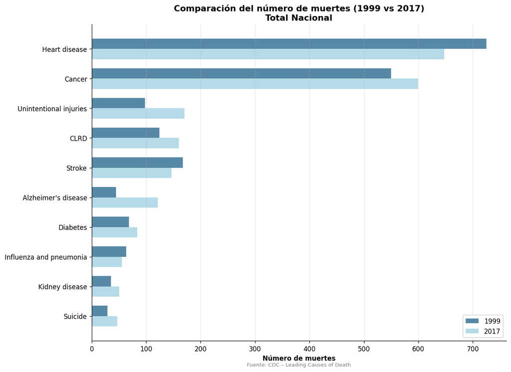

```python
comparacion = datos[
    (datos['anio'].isin([1999, 2017])) &
    (datos['causa'] != 'All causes')
][['anio', 'causa', 'muertes']].copy()
comparacion['anio'] = comparacion['anio'].astype(str)

orden = (
    comparacion[comparacion['anio'] == '2017']
    .sort_values('muertes')['causa'].tolist()
)
pivot_comp = comparacion.pivot(index='causa', columns='anio', values='muertes').loc[orden]

fig, ax = plt.subplots(figsize=(11, 8))
y = np.arange(len(pivot_comp))
h = 0.35
ax.barh(y + h/2, pivot_comp['1999'], h, label='1999', color='#457B9D', alpha=0.9)
ax.barh(y - h/2, pivot_comp['2017'], h, label='2017', color='#ADD8E6', alpha=0.9)

ax.set_yticks(y)
ax.set_yticklabels(pivot_comp.index, fontsize=10)
ax.set_xlabel('Número de muertes', fontweight='bold')
ax.set_title('Comparación del número de muertes (1999 vs 2017)\nTotal Nacional',
             fontsize=13, fontweight='bold')
ax.xaxis.set_major_formatter(mticker.FuncFormatter(lambda x, _: f'{x:,.0f}'))
ax.legend(loc='lower right')
ax.grid(axis='x', alpha=0.3)
ax.spines['top'].set_visible(False); ax.spines['right'].set_visible(False)
ax.text(0.5, -0.08, 'Fuente: CDC – Leading Causes of Death',
        transform=ax.transAxes, ha='center', fontsize=8, color='gray')
plt.tight_layout()
plt.show()
```

### 9.2. Evolución de la tasa ajustada de Virginia

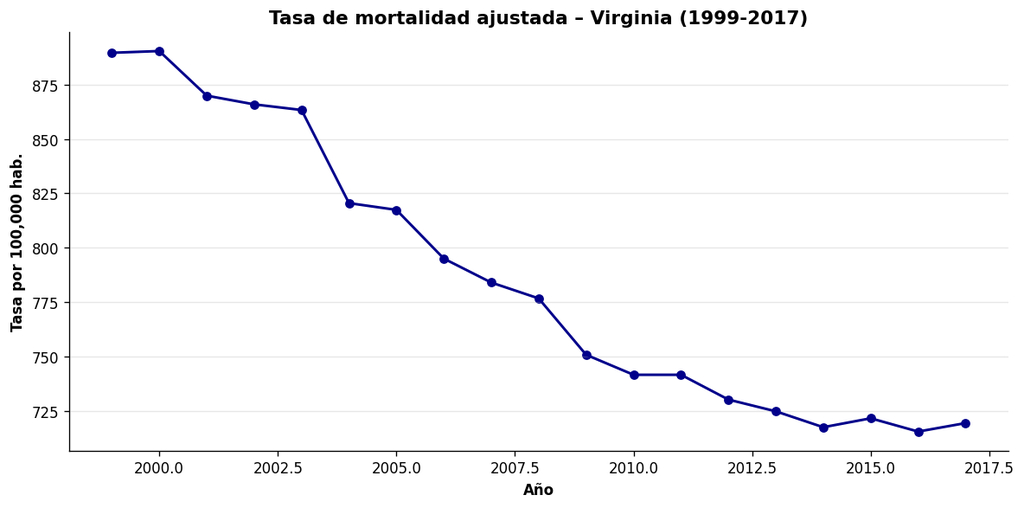

```python
# Equivalente al código R con datos_limpios filtrado por Virginia
virginia = datos_estados[
    (datos_estados['estado'] == 'Virginia') &
    (datos_estados['causa'] == 'All causes')
].sort_values('anio')

fig, ax = plt.subplots(figsize=(10, 5))
ax.plot(virginia['anio'], virginia['tasa_ajustada'],
        color='darkblue', linewidth=1.8)
ax.scatter(virginia['anio'], virginia['tasa_ajustada'], color='darkblue', s=30)
ax.set_title('Tasa de mortalidad ajustada – Virginia (1999-2017)',
             fontsize=13, fontweight='bold')
ax.set_xlabel('Año', fontweight='bold')
ax.set_ylabel('Tasa por 100,000 hab.', fontweight='bold')
ax.grid(axis='y', alpha=0.3)
ax.spines['top'].set_visible(False); ax.spines['right'].set_visible(False)
plt.tight_layout()
plt.show()
```

### 9.3. Comparación: Virginia vs. Promedio Nacional

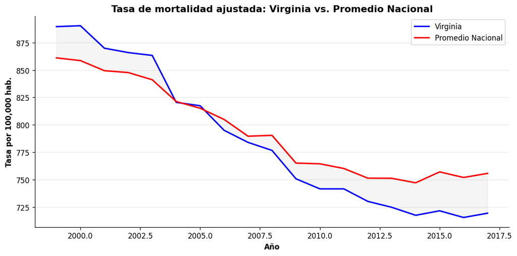

```python
promedio_nac = (
    datos_estados[datos_estados['causa'] == 'All causes']
    .groupby('anio')['tasa_ajustada']
    .mean()
    .reset_index(name='tasa_promedio')
)

comparacion_va = virginia.merge(promedio_nac, on='anio')

fig, ax = plt.subplots(figsize=(10, 5))
ax.plot(comparacion_va['anio'], comparacion_va['tasa_ajustada'],
        color='blue', linewidth=2, label='Virginia')
ax.plot(comparacion_va['anio'], comparacion_va['tasa_promedio'],
        color='red', linewidth=2, label='Promedio Nacional')
ax.fill_between(comparacion_va['anio'],
                comparacion_va['tasa_ajustada'],
                comparacion_va['tasa_promedio'],
                alpha=0.08, color='gray')
ax.set_title('Tasa de mortalidad ajustada: Virginia vs. Promedio Nacional',
             fontsize=13, fontweight='bold')
ax.set_xlabel('Año', fontweight='bold')
ax.set_ylabel('Tasa por 100,000 hab.', fontweight='bold')
ax.legend()
ax.grid(axis='y', alpha=0.3)
ax.spines['top'].set_visible(False); ax.spines['right'].set_visible(False)
plt.tight_layout()
plt.show()
```

```python
# Ranking de Virginia en 2017 por tasa ajustada
ranking_2017 = (
    datos_estados[
        (datos_estados['anio'] == 2017) &
        (datos_estados['causa'] == 'All causes')
    ]
    .sort_values('tasa_ajustada', ascending=False)
    .reset_index(drop=True)
)
ranking_2017.index += 1  # 1-indexed

pos_virginia = ranking_2017[ranking_2017['estado'] == 'Virginia'].index.tolist()
print(f"Posición de Virginia en el ranking de tasa ajustada 2017: {pos_virginia}")
print(ranking_2017[['estado', 'tasa_ajustada']].head(10).to_string())
```

```
Posición de Virginia en el ranking de tasa ajustada 2017: [31]
           estado  tasa_ajustada
1   West Virginia          957.1
2     Mississippi          951.3
3        Kentucky          929.9
4         Alabama          917.7
5        Oklahoma          902.4
6        Arkansas          900.1
7       Tennessee          897.1
8       Louisiana          881.1
9            Ohio          849.7
10        Indiana          848.6
```

## 9.2. Insights Clave

### Insight 1: El dominio inquebrantable de las enfermedades crónicas

Las enfermedades cardíacas y el cáncer mantienen su posición como las dos principales causas de muerte durante todo el período (1999‑2017). Aunque ambas lideran, las cardíacas muestran un descenso sostenido (de 260 a 165 por 100,000), reflejando avances en prevención y tratamiento, mientras que el cáncer se mantiene más estable. Este doble patrón confirma el predominio de las enfermedades crónicas en la transición epidemiológica (Shah et al., 2019).

### Insight 2: La crisis silenciosa de las "muertes por desesperación"

Suicidios y lesiones no intencionales aumentan de forma preocupante, con estas últimas superando 48 por 100,000 en 2017 y una aceleración desde 2014. Este fenómeno, vinculado a la crisis de opioides y al deterioro socioeconómico (Daugherty et al., 2019), contrasta con la disminución de otras causas y evidencia la necesidad de abordar determinantes sociales.

### Insight 4: El Alzheimer emerge como un desafío creciente

El Alzheimer asciende del puesto 8 al 6 con un incremento del 173% en muertes, el más alto entre todas las causas. Su curva ascendente refleja el envejecimiento poblacional y plantea retos sanitarios y sociales crecientes ante la falta de tratamientos curativos (Shah et al., 2019).

### Insight 5: El ranking es dinámico, pero el top 2 es inamovible

Mientras causas como lesiones no intencionales (del puesto 5 al 3) y Alzheimer (del 8 al 6) ganan posiciones, y el stroke desciende (del 3 al 5), las enfermedades cardíacas y el cáncer se mantienen inalterables en los dos primeros lugares. Esta movilidad refleja cambios epidemiológicos, pero subraya la persistente dominancia de las enfermedades crónicas.

### Insight 6: La carga de mortalidad se concentra geográficamente

California, Texas, Florida y Nueva York concentran el mayor volumen absoluto de muertes por su alta densidad poblacional. Sin embargo, esto contrasta con sus bajas tasas ajustadas, evidenciando la diferencia entre **carga absoluta** (demanda asistencial) y **riesgo relativo** (probabilidad de morir), lo que orienta la asignación de recursos a diferentes escalas.

## 10. Limitaciones del Estudio

- **Naturaleza observacional:** Los datos utilizados son de carácter observacional y agregado, por lo que permiten identificar correlaciones pero no establecer causalidad. No es posible determinar, por ejemplo, si el aumento de accidentes se debe a la crisis de opioides o a otros factores no medidos.
- **Ventana temporal acotada:** El análisis cubre hasta 2017, por lo que no incorpora el impacto de la pandemia de COVID-19 ni los cambios más recientes en la mortalidad por opioides. Los patrones observados pueden haber variado después de 2020.
- **Falta de variables demográficas clave:** El dataset no incluye desagregación por sexo, edad o raza, lo que limita el análisis de desigualdades intrapoblacionales. No podemos cuantificar, por ejemplo, la brecha de género en enfermedades cardíacas o el impacto diferencial de la crisis de opioides por grupo étnico.
- **Agregación nacional vs. estatal:** El análisis por estado se basa en promedios que pueden ocultar heterogeneidades internas. Por ejemplo, dentro de California existen condados con tasas de mortalidad muy diferentes.

## 11. Conclusiones

Estas evidencias exigen:

1. **Políticas de salud pública diferenciadas** que concentren recursos en los territorios con mayor carga de mortalidad y aborden los determinantes sociales subyacentes.
2. **Un abordaje integral de la crisis de opioides y la salud mental** que combine control de sustancias, acceso a tratamientos y apoyo psicosocial.
3. **Preparación del sistema sanitario para el envejecimiento poblacional** mediante el fortalecimiento de la atención geriátrica y la investigación en enfermedades neurodegenerativas.

> *Los datos son claros: el perfil de mortalidad ha cambiado, pero las respuestas institucionales aún no están a la altura de estos nuevos desafíos; es hora de pasar de un enfoque reactivo a uno proactivo que combine la prevención de enfermedades crónicas con una acción decidida sobre los determinantes sociales, las adicciones y el envejecimiento para avanzar hacia un futuro con menos muertes evitables y mayor equidad en salud.*

## 12. Referencias Bibliográficas

- James, W., Cossman, J., & Wolf, J. K. (2018). Persistence of death in the United States: The remarkably different mortality patterns between America's Heartland and Dixieland. *Demographic Research, 39*, 897–910. https://doi.org/10.4054/DemRes.2018.39.33
- Shah, N. S., Lloyd-Jones, D. M., O'Flaherty, M., Capewell, S., Kershaw, K. N., Carnethon, M., & Khan, S. S. (2019). Trends in cardiometabolic mortality in the United States, 1999-2017. *JAMA, 322*(8), 780–782. https://doi.org/10.1001/jama.2019.11245
- Daugherty, J., Waltzman, D., Sarmiento, K., & Xu, L. (2019). Traumatic brain injury–related deaths by race/ethnicity, sex, intent, and mechanism of injury — United States, 2000–2017. *MMWR. Morbidity and Mortality Weekly Report, 68*(46), 1050–1056. https://doi.org/10.15585/mmwr.mm6846a2